# Unsupervised Learning Capstone

-Segmentation of FIFA Players

# Context and Motivation

There are over 18,000 players in the league. For a manager trying to assemble a team on a budget or rebuild a program by selecting cheaper players with potential this can be a prohibitively large number to sort by hand.

Using unsupervised learning techniques players can be segmented to reduce manual searching.

## Guiding questions:

- Are there distinct groups within the population of players?
- What makes them different from one another?
- Can we uncover previously unseen information about their value?

## Potential to Add Value

- Can we provide recruiters with better leads?

### About the Data

#### Dataset is Inherently flawed but the best complete information out there

These rankings make news every year when they come out and players and fans alike have strong opinions about the accuracy of the scores. These headline figures are the most biased but luckily there is also included in this dataset the raw data used to calculate the headline figures which the group openly admits to manually altering in some instances.

#### 35 Attributes are scored by 9000 survey participants

- Feedback comes mostly from fans who watch games in person
- These numbers have not been manually altered

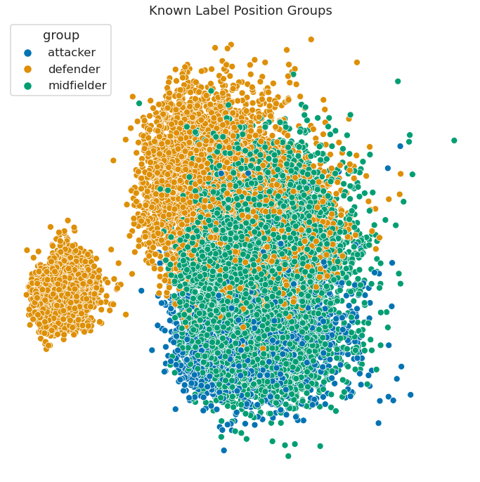

# Methods

## Assumptions

- Clustering using the raw attribute scores only

### Clustering Technologies Used

- K-Means
- DBSCAN
- Heirarchical Clustering
- Mean-Shift

## Segmentation Outcomes

- Separated Keepers and Fielders
- Applied a Variety of models and compared the resulting outputs

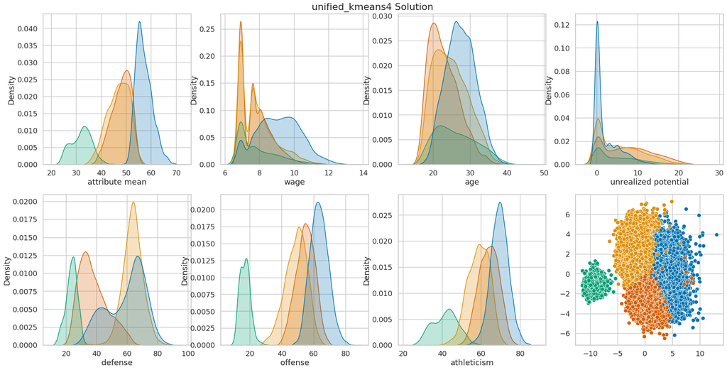

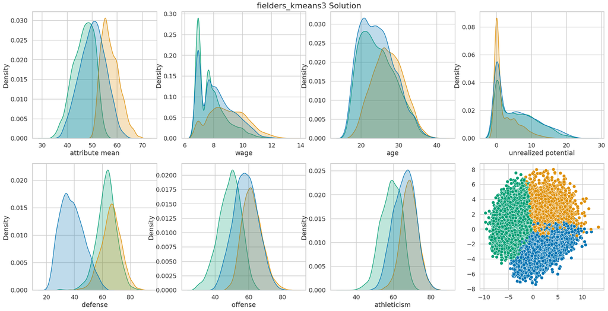

## Actionable Insights

### 3 Cluster Labels for Fielders

- High Performers
  - Expensive
  - Not generally as much room for growth
- Good Value
  - Much cheaper overall than the first group
  - Decent performance
  - Generally room for grown
- Defenders / Ignore
  - Some of these players are solid defenders
  - All of them are cheap
  - Less potential for growth overall than Good Value but more than High Performers

## Keepers lacked a distinct middle group

Segmentation identified one group of players to avoid and one group of reliable performers.

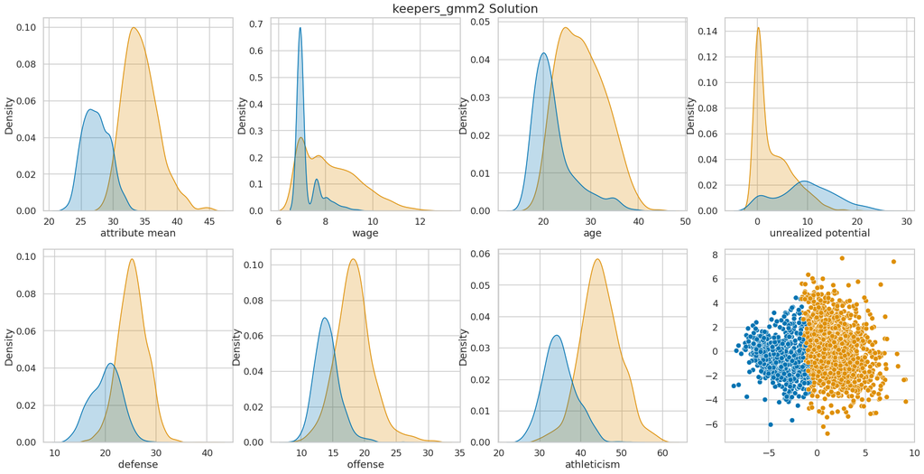